# Forest Plots

[0 - 0.011)

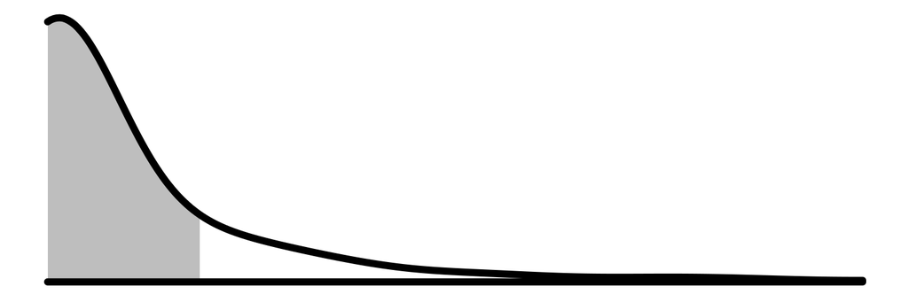

355 (56.9%)

247 (69.6%)

[0.011 - Inf)

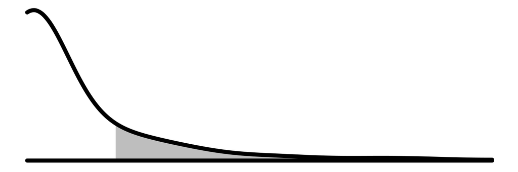

73 (11.7%)

58 (79.5%)

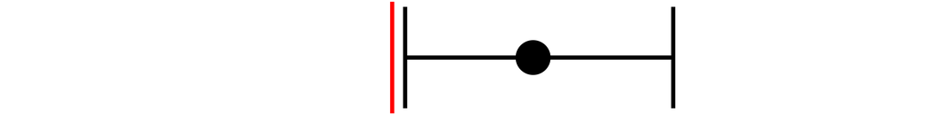

1.9 (1.1-3.7)

0.03814 *

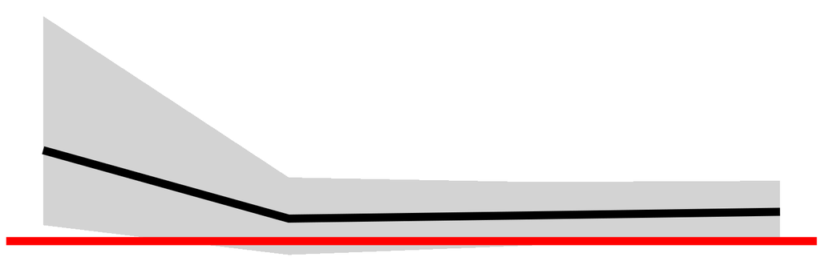

missing

196 (31.4%)

134 (68.4%)

Median AE Reporting Delay (days)

[0 - 27)

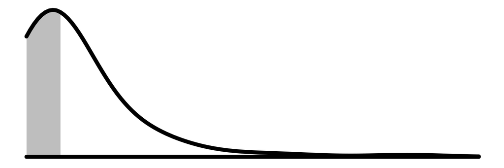

206 (33%)

131 (63.6%)

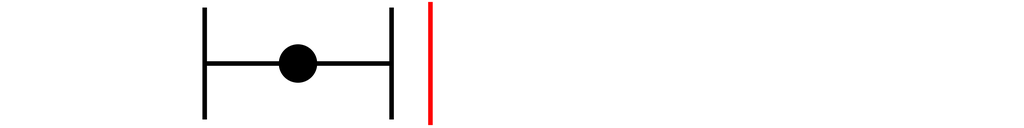

0.6 (0.4-0.8)

0.00541 *

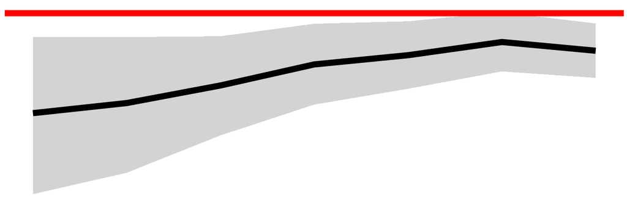

[27 - Inf)

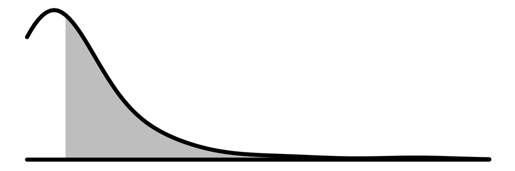

179 (28.7%)

136 (76%)

missing

239 (38.3%)

172 (72%)

Median Query Processing Time (days)

[0 - 2)

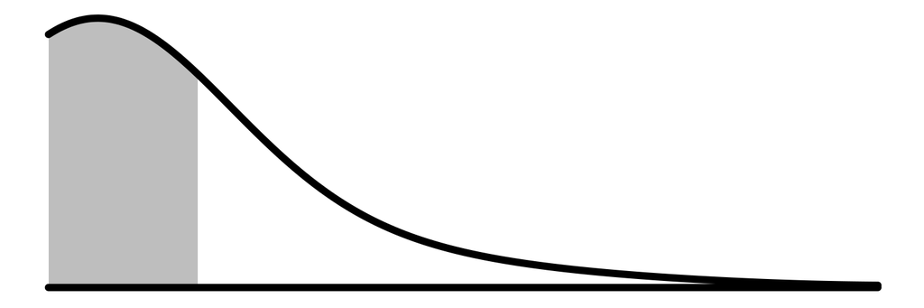

207 (33.2%)

140 (67.6%)

[2 - 5)

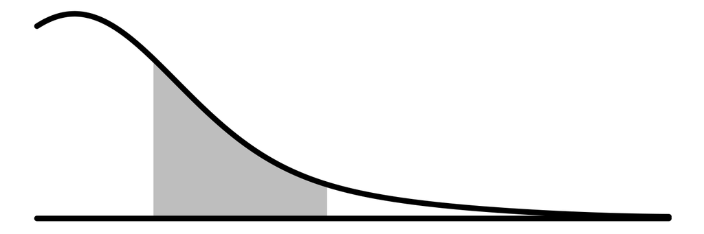

52 (8.3%)

40 (76.9%)

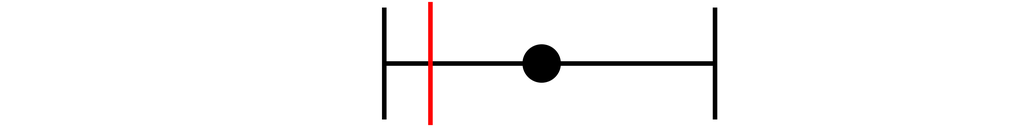

1.6 (0.8-3.3)

0.18389

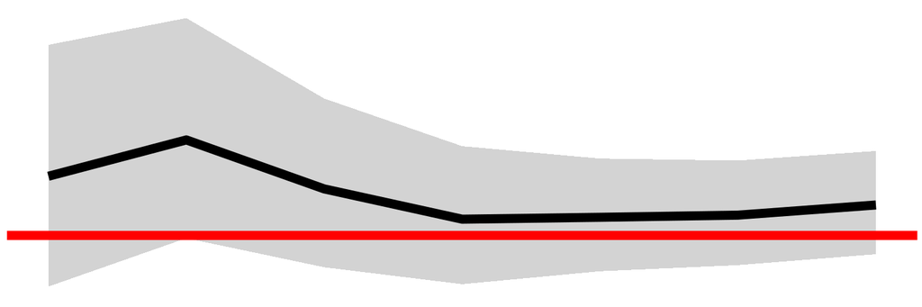

[5 - Inf)

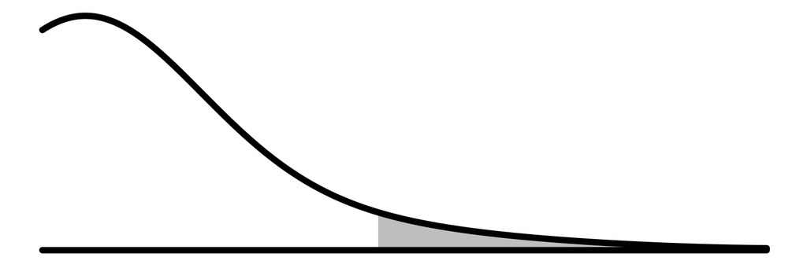

19 (3%)

16 (84.2%)

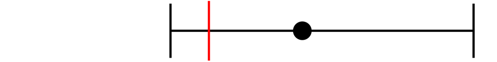

2.2 (0.7-9.9)

0.21083

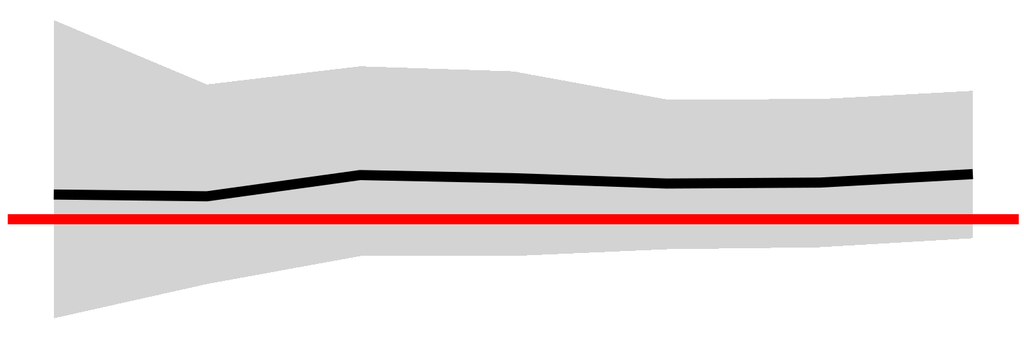

missing

346 (55.4%)

243 (70.2%)

<sup>*1*</sup> Number of Clinical Trial Site Audits and Inspections

<sup>*2*</sup> Red Reference Line Indicates Zero

<sup>*3*</sup> Coefficient Value as New Data is Successively Added from 2011-2019

<sup>*4*</sup> Sum of Days Since Enrollment of All Patients